# SDUSD Teacher Retention & CBS Strategy Report

Retention Rate, Shifting Rate & Capacity-Building Strategies (CBS) Trends

Published

July 27, 2026

This report summarizes teacher retention rate, teacher shifting rate, and Capacity-Building Strategies (CBS) scores for 35 schools across the 2020-21 through 2024-25 academic years. Use the **Overall**, **By Cohort**, and **By School** sections below to explore the trend plots, and the **Correlation Analysis** section for how retention/shifting relate to CBS strategies and other APR variables.

## Overall

**Retention Rate**

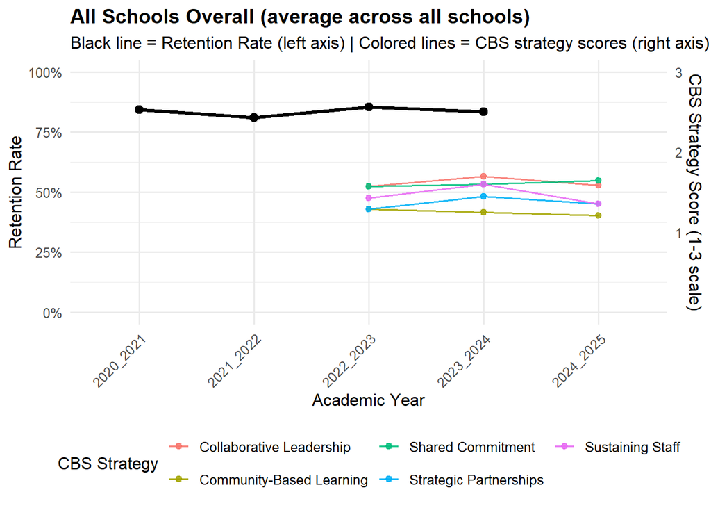

**Shifting Rate**

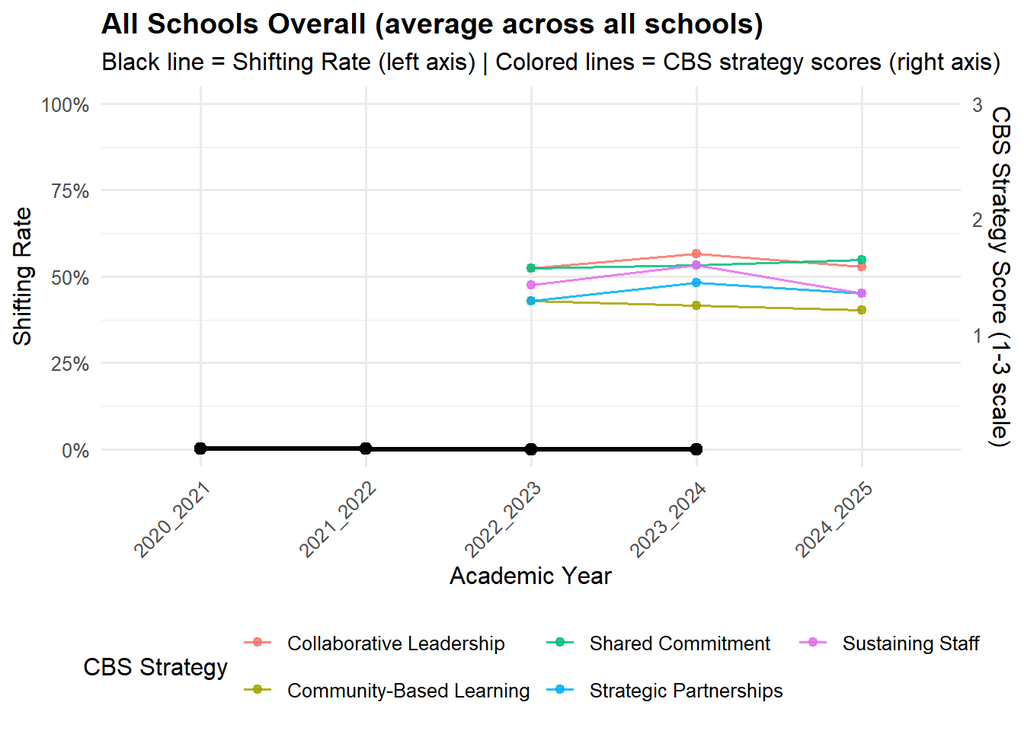

**Combined**

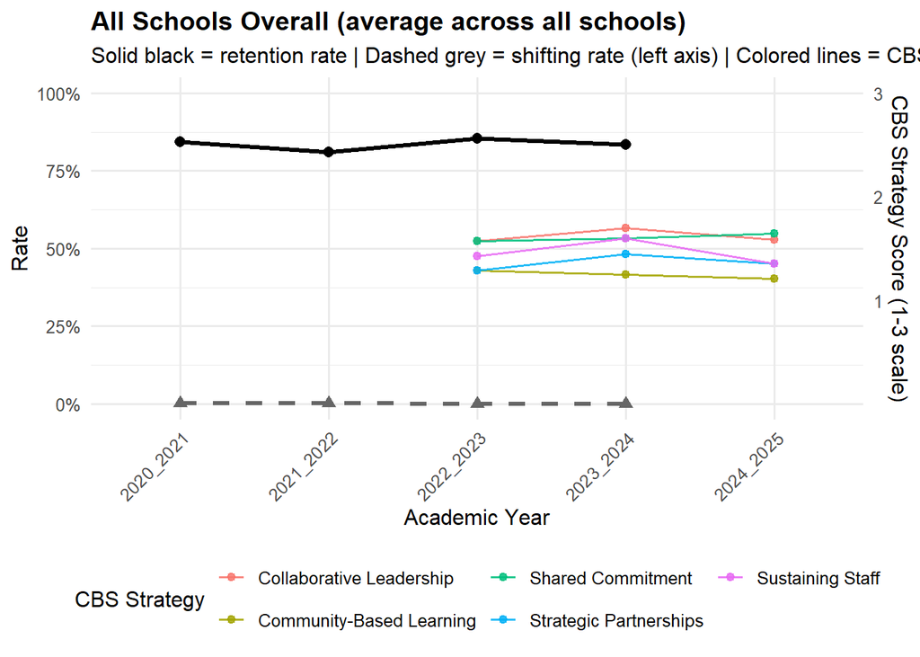

## By Cohort

### CCSPP Cohort

#### Cohort 1

**Retention Rate**

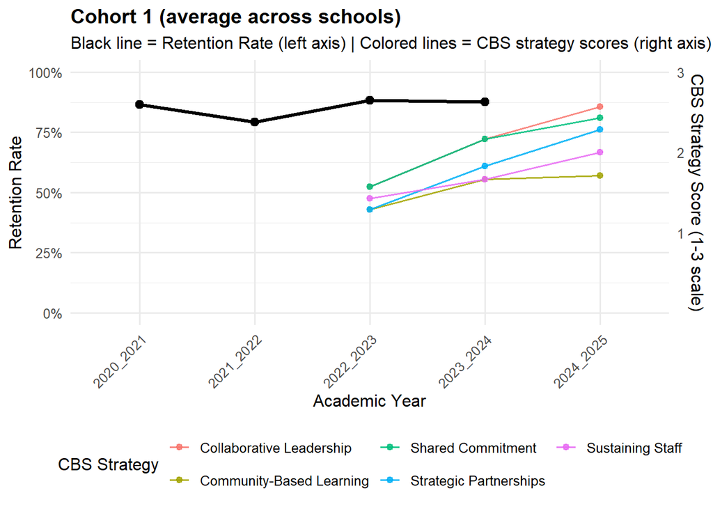

**Shifting Rate**

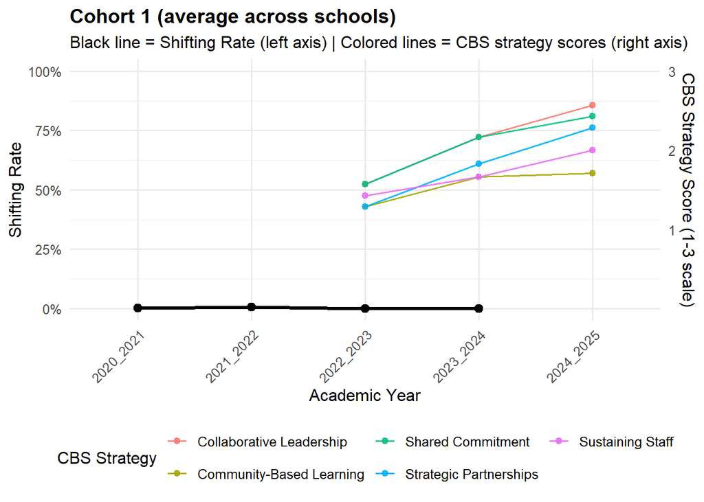

**Combined**

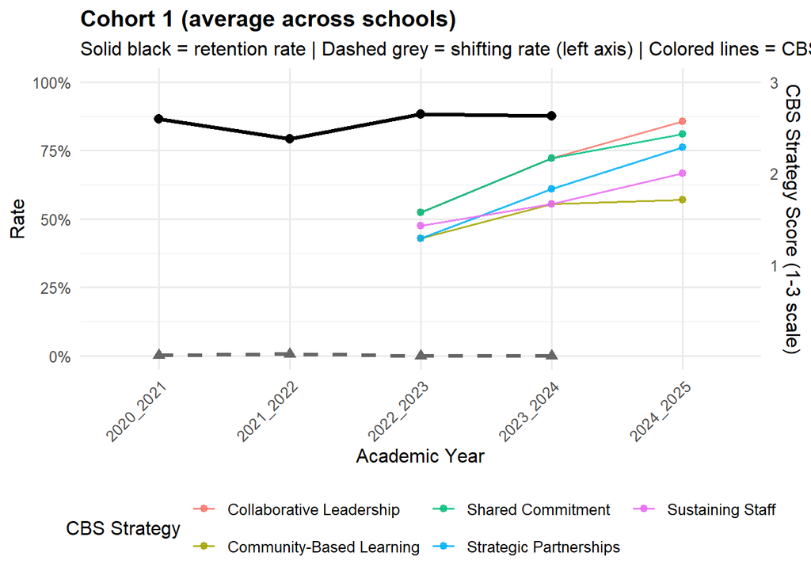

#### Cohort 2

**Retention Rate**

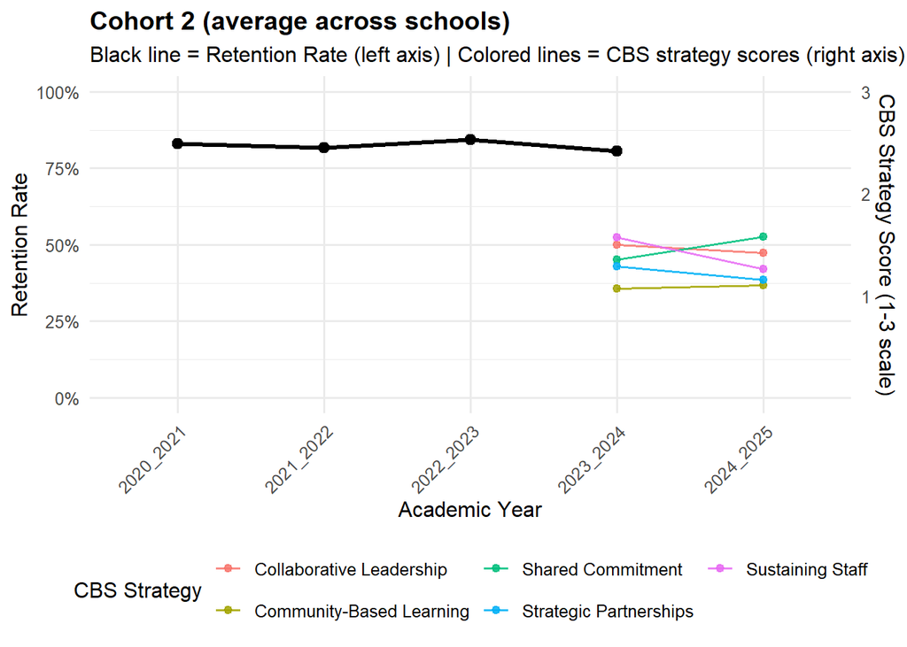

**Shifting Rate**

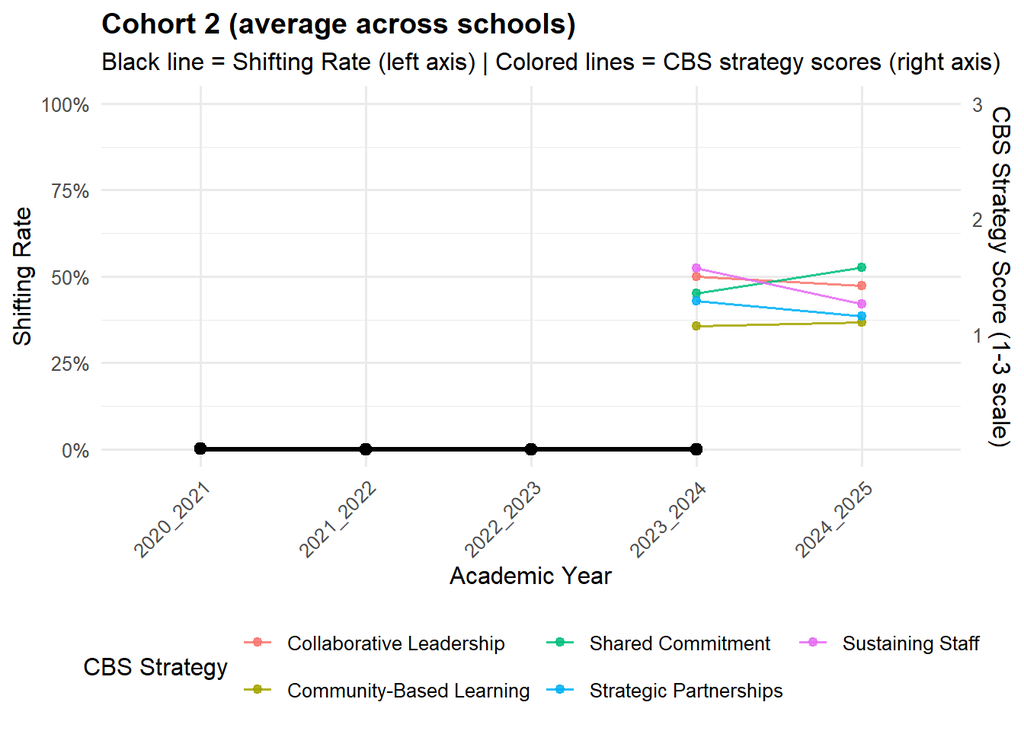

**Combined**

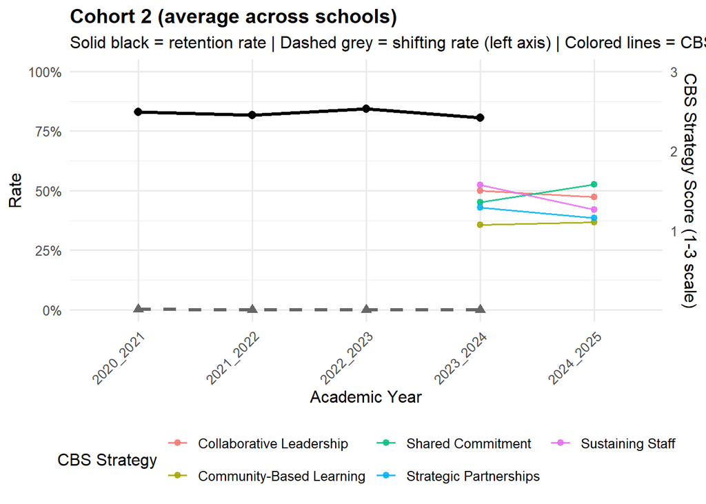

#### Cohort 3

**Retention Rate**

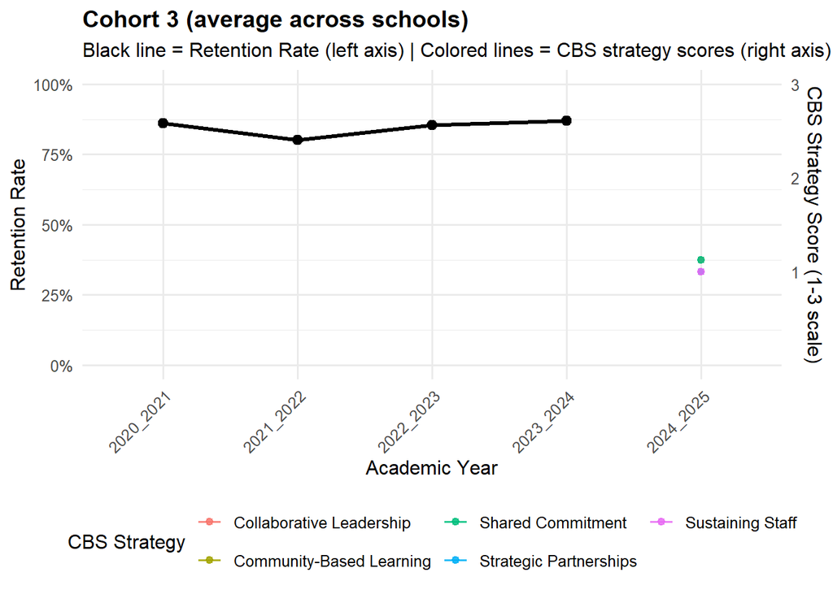

**Shifting Rate**

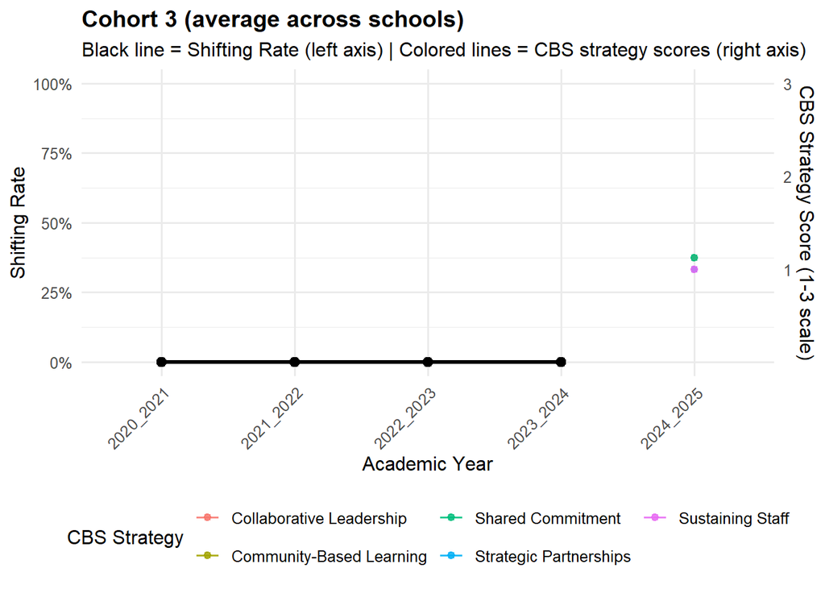

**Combined**

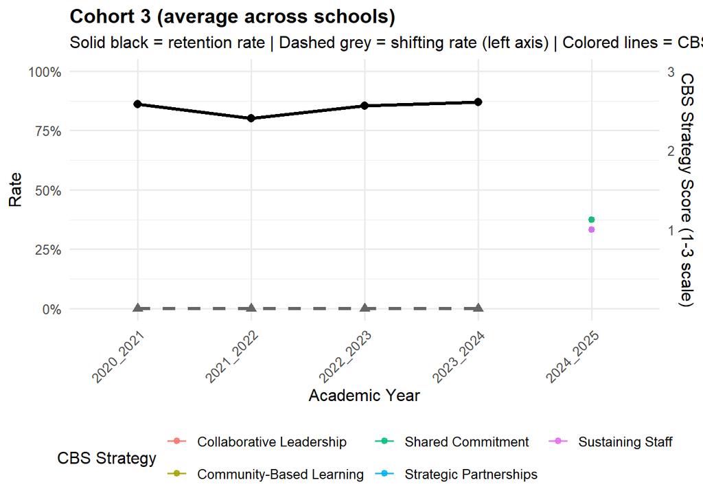

### SDUSD Cohort

#### SD Cohort 1

**Retention Rate**

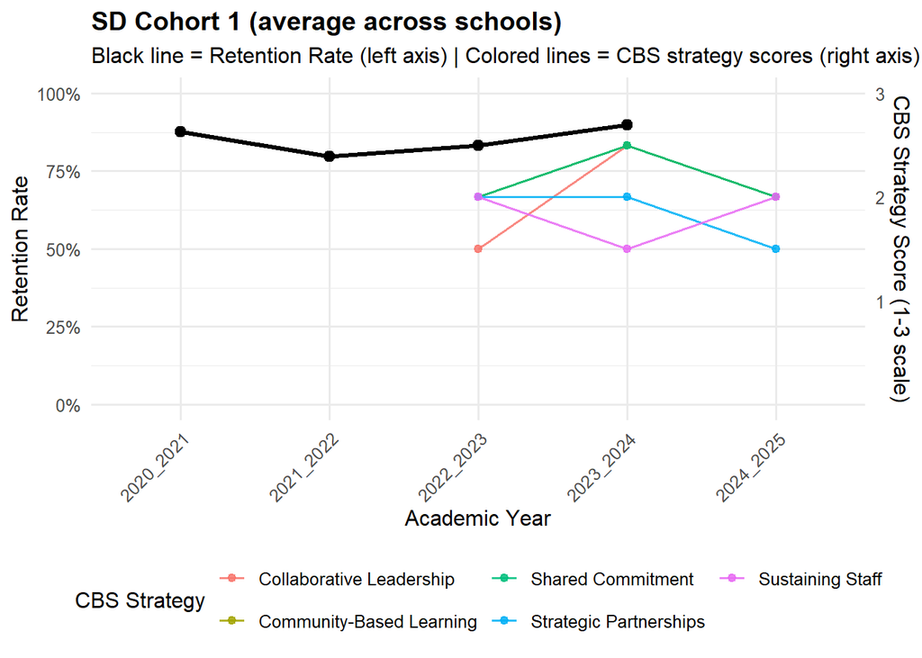

**Shifting Rate**

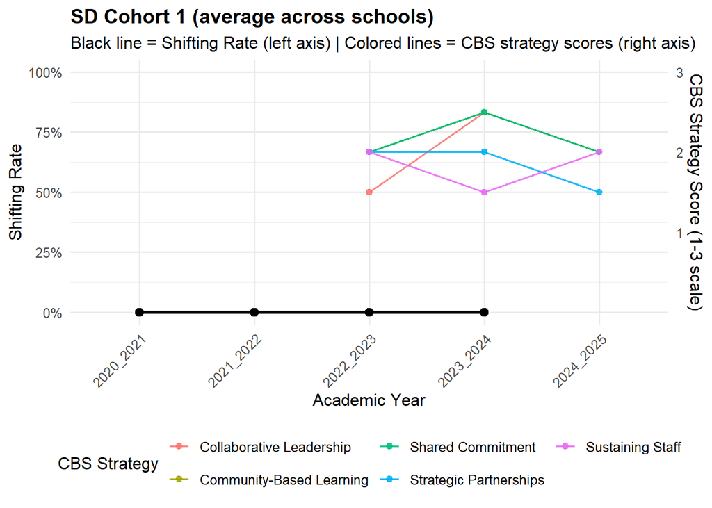

**Combined**

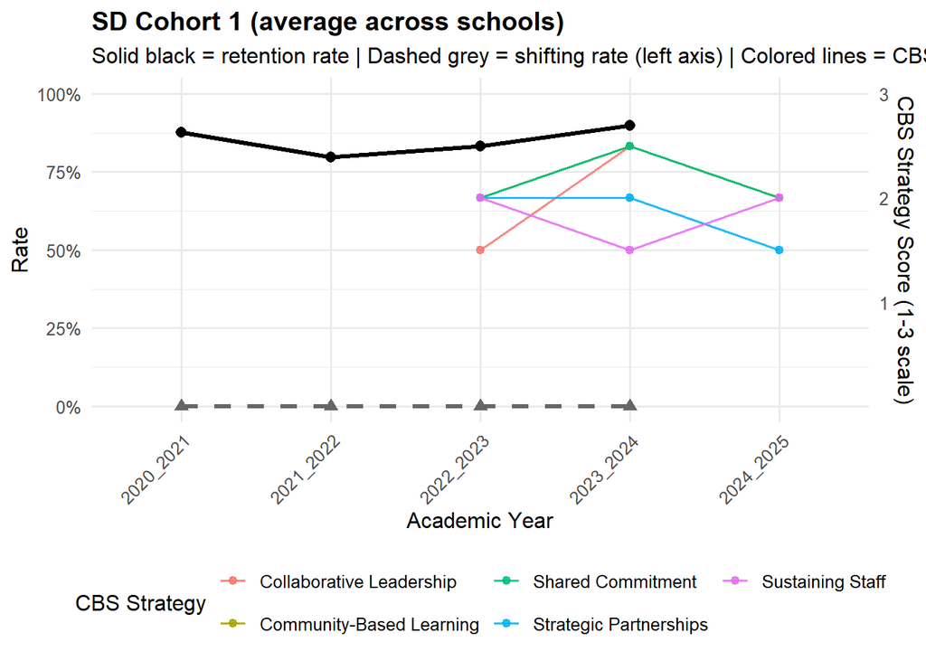

#### SD Cohort 2

**Retention Rate**

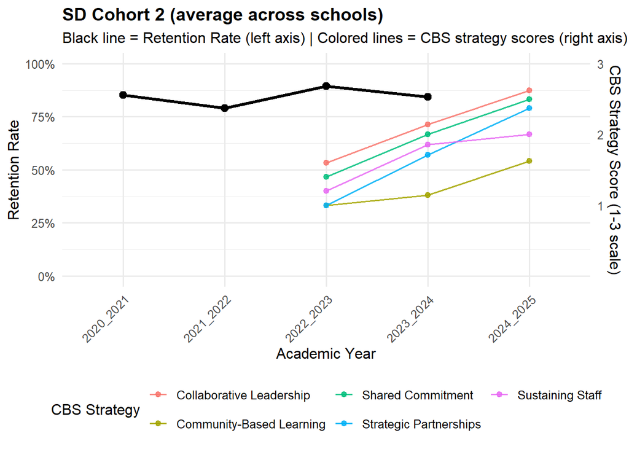

**Shifting Rate**

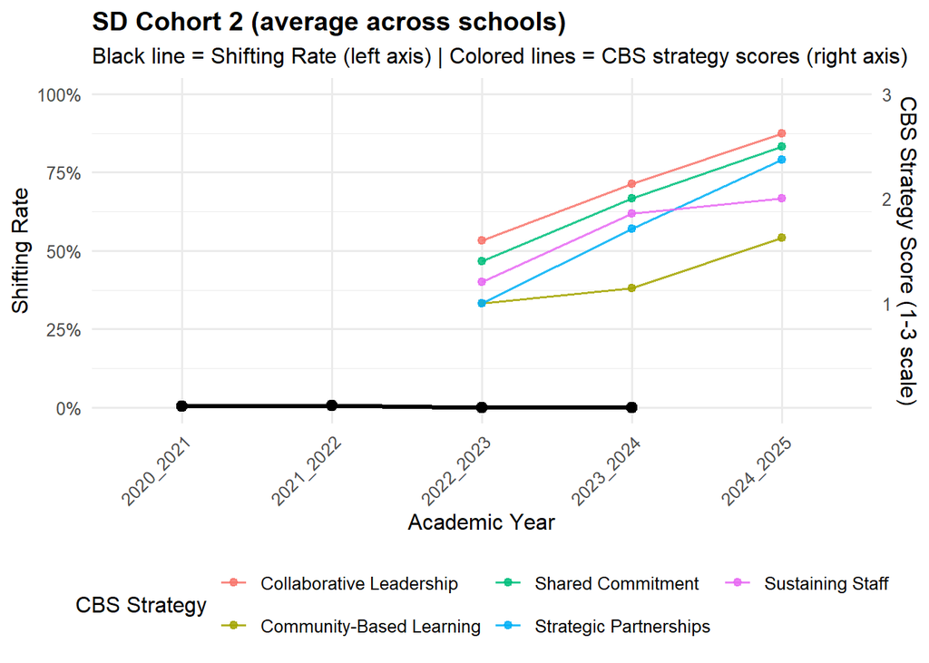

**Combined**

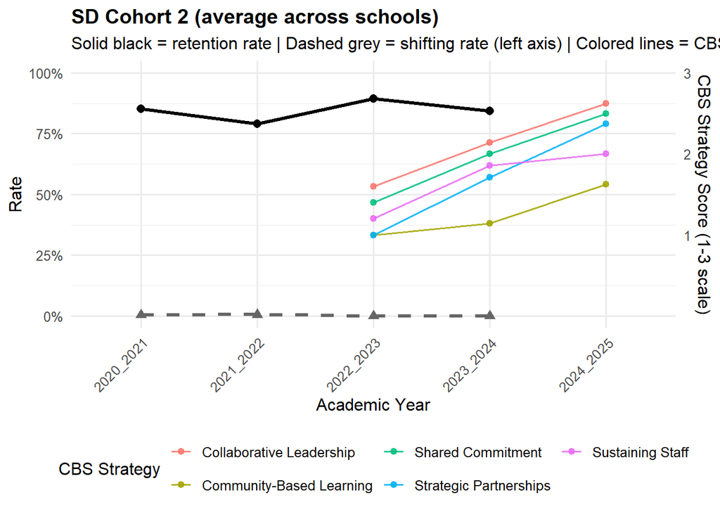

#### SD Cohort 3

**Retention Rate**

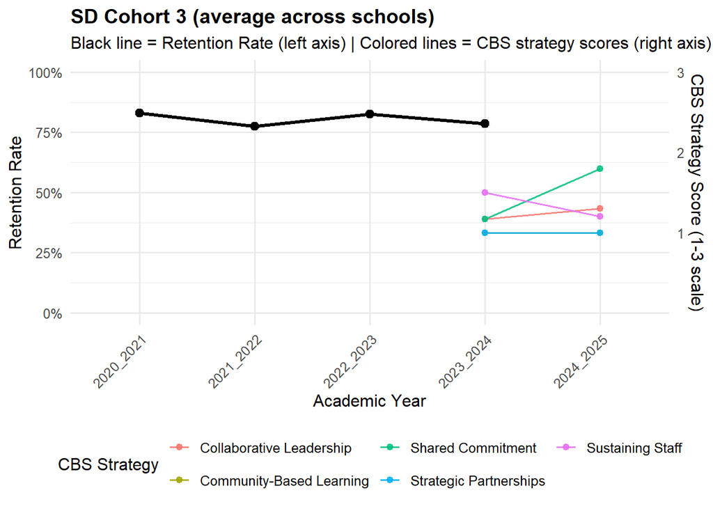

**Shifting Rate**

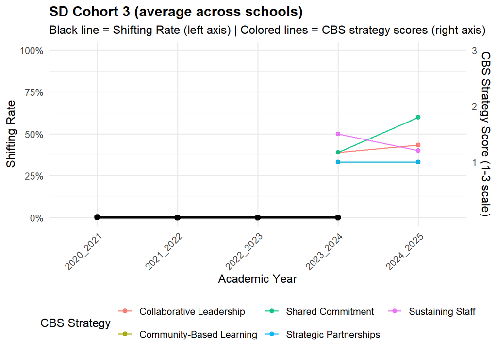

**Combined**

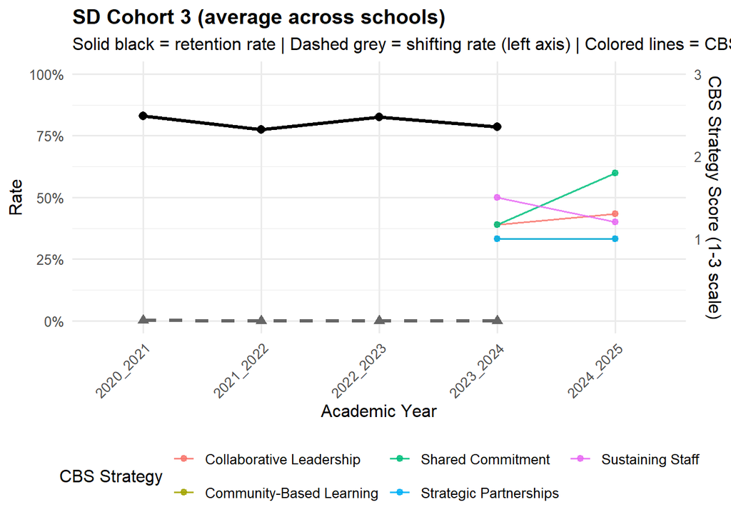

#### SD Cohort 4

**Retention Rate**

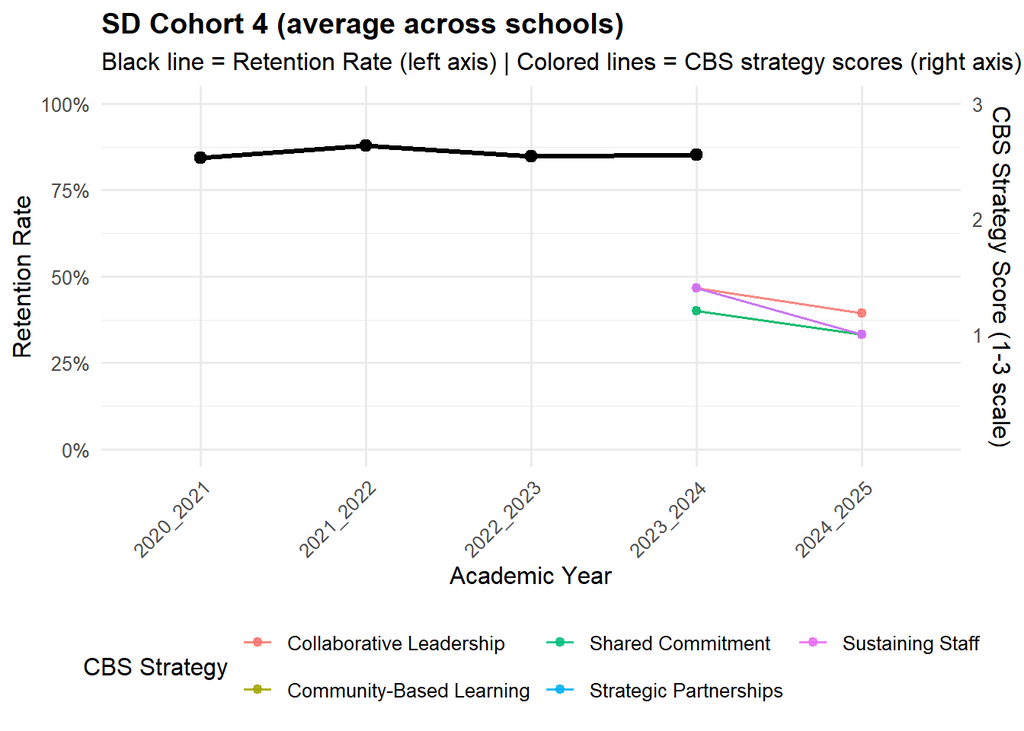

**Shifting Rate**

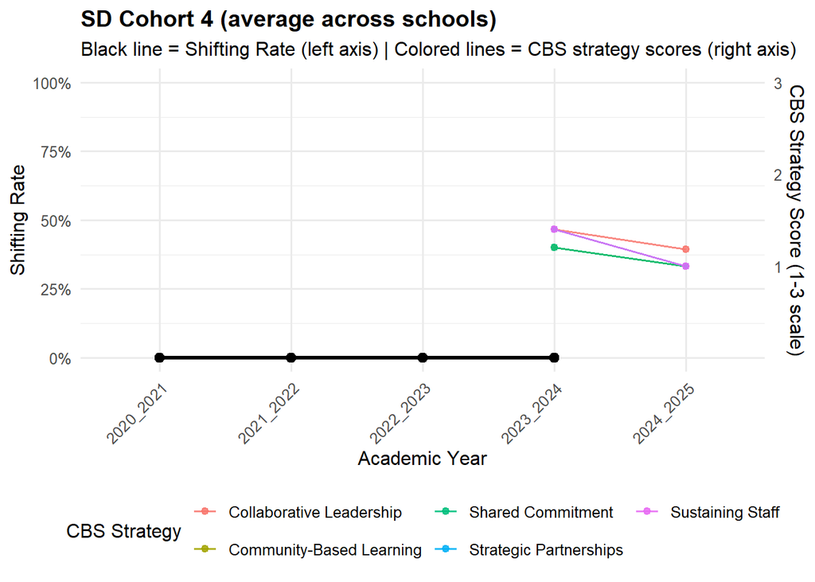

**Combined**

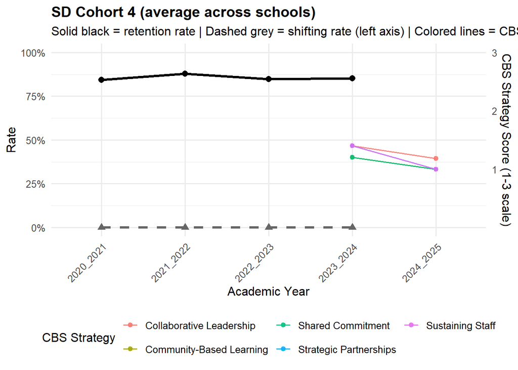

## By School

Pick a school from the dropdown to see its retention/shifting/combined trend plots.

**Select a school:**

#### Baker Elementary

**Retention Rate**

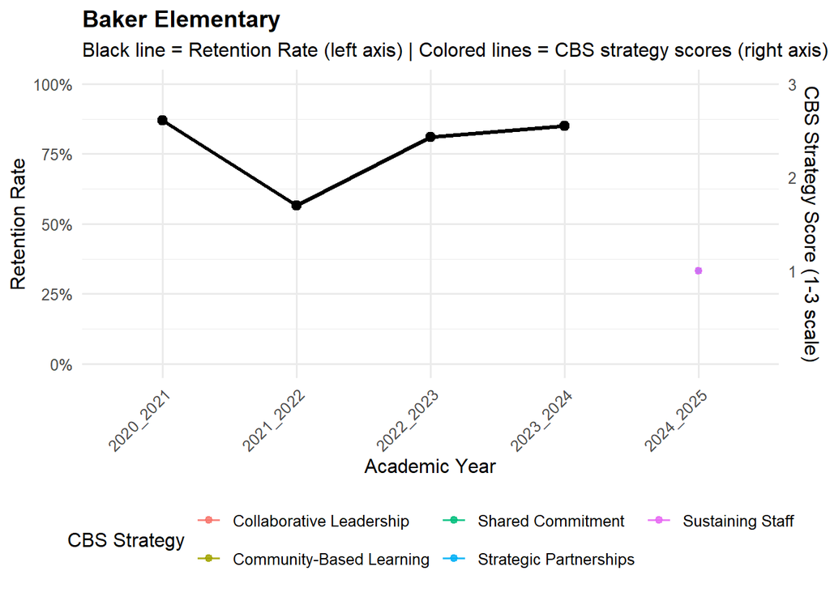

**Shifting Rate**

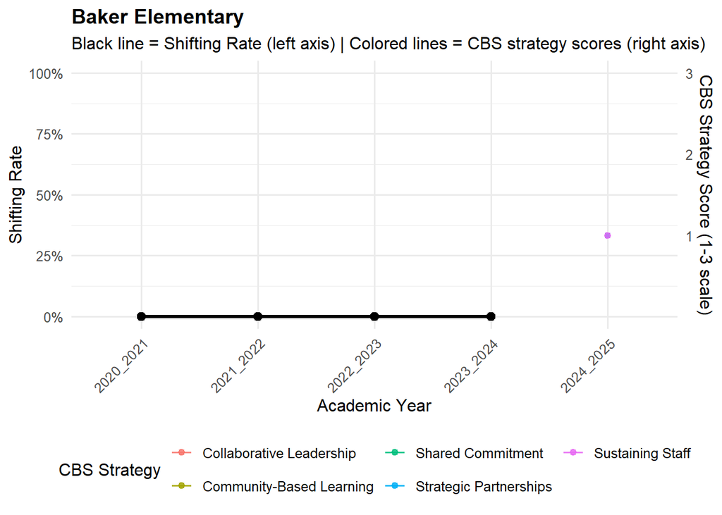

**Combined**

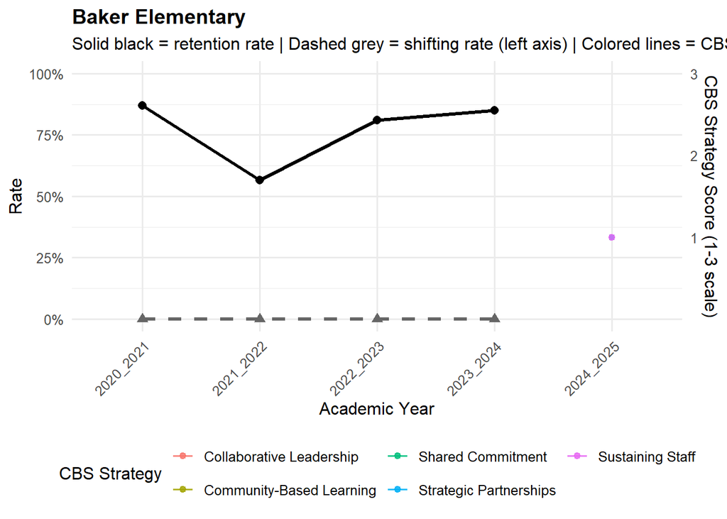

#### Bell Middle

**Retention Rate**

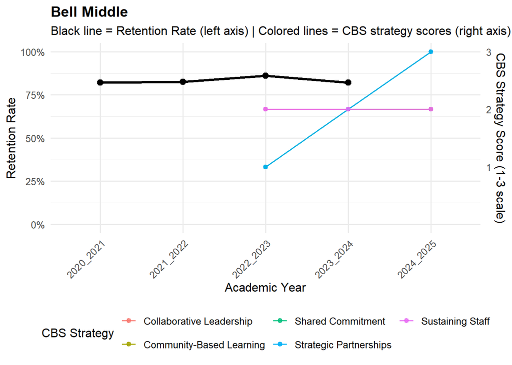

**Shifting Rate**

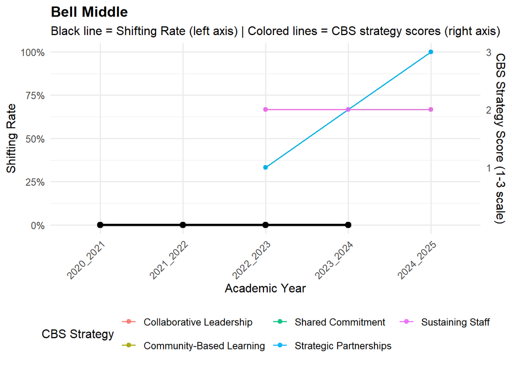

**Combined**

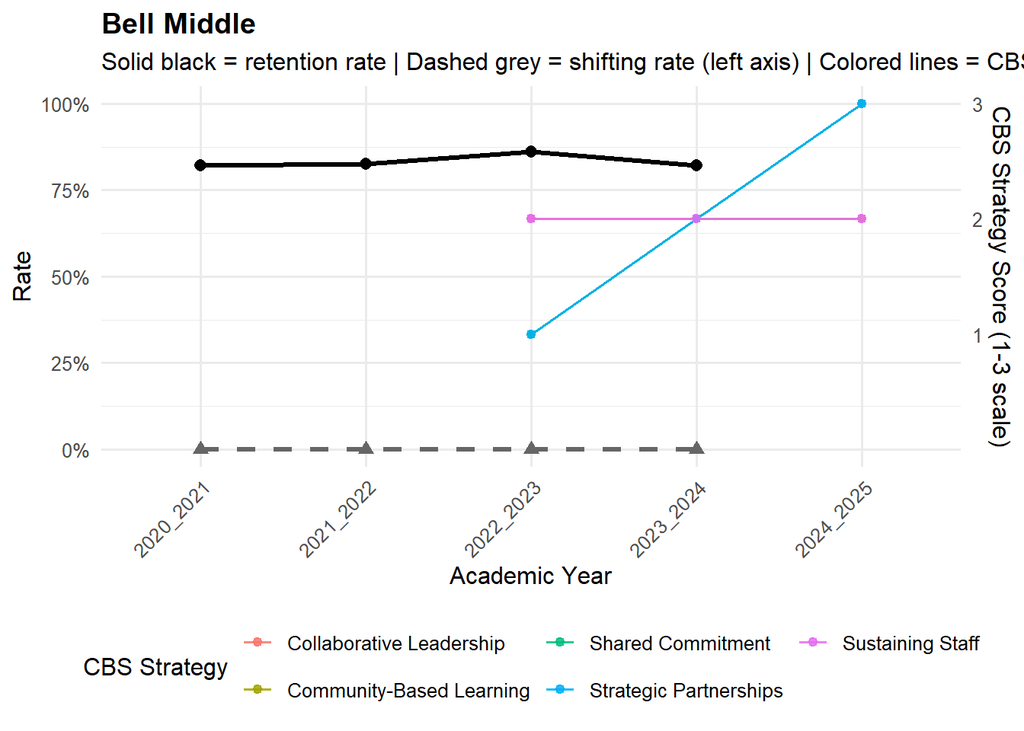